# Changes on CRAN

Abstract

The “Changes on CRAN” article from the 2019-1 issue.

2019-01-01 to 2019-08-31

In the past 8 months, 1524 new packages were added to the CRAN package repository. 71 packages were unarchived and 302 were archived. The following shows the growth of the number of active packages in the CRAN package repository:

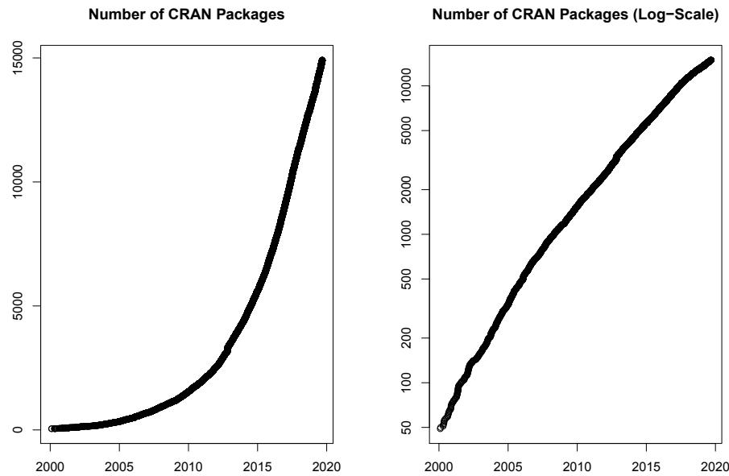

On 2019-08-31, the number of active packages was around 14882.

## Changes in the CRAN Repository Policy

The Policy now says the following:

- Packages should not attempt to disable compiler diagnostics, nor to remove other diagnostic information such as symbols in shared objects.

## CRAN package submissions

Minus some special cases, a summary of the auto-processed and manually triggered actions follows:

|  | archive | inspect | newbies | pending | publish | recheck | waiting |
| --- | --- | --- | --- | --- | --- | --- | --- |
| auto | 3300 | 2419 | 3130 | 32 | 3894 | 1202 | 879 |
| manual | 3198 | 14 | 428 | 76 | 2728 | 642 | 270 |

New categories in the table above are *newbies* (a specific queue for the manual inspection of first time CRAN submissions) and *waiting* (packages for which the CRAN team waits for an answer from the maintainer).

These include the final decisions for the submissions which were where we only count those as *auto* processed whose publication or rejection happened automatically in all steps.

[output not shown]

The CRAN team has grown. While Swetlana Herbrandt is very active in processing the *newbies* queue voluntarily, the new team members Martina Schmirl and Matthias Sterrer joined and processed a lot of packages during the first half of the year. Recently Matthias has left and Jelena Saf joined the team. Thanks a lot!

## CRAN mirror security

Currently, there are 93 official CRAN mirrors, 63 of which provide both secure downloads via ‘https’ *and* use secure mirroring from the CRAN master (via rsync through ssh tunnels). Since the R 3.4.0 release, `chooseCRANmirror()` offers these mirrors in preference to the others which are not fully secured (yet).

## New CRAN task views

*Hydrology* Topic: Hydrological Data and Modeling. Maintainer: Sam Zipper, Sam Albers, Ilaria Prosdocimi. Packages: *CityWaterBalance*, *CoSMoS*, *EGRET*, *EGRETci*, *EcoHydRology**, *Ecohydmod*, *Evapotranspiration*, *FAdist*, *FlowScreen*, *GSODR*, *GWSDAT*, *HydroMe*, *IDF*, *LPM*, *MBC*, *MODISTools*, *MODISTsp*, *RHMS*, *RMAWGEN*, *RNCEP*, *RSAlgaeR*, *SCI*, *SPEI*, *SWATmodel*, *TUWmodel*, *WRSS*, *WRTD-Stidal*, *WaterML*, *Watersheds*, *airGR*, *airGRteaching*, *berryFunctions*, *bigleaf*, *biotic*, *bomrang*, *boussinesq*, *clifro*, *climatol*, *climdex.pcic*, *countyweather*, *dataRetrieval*, *dbhydroR*, *driftR*, *dynatopmodel*, *ecoval*, *geoknife*, *geotopbricks*, *getMet*, *hddtools*, *humidity*, *hydroApps*, *hydroGOF**, *hydroPSO*, *hydroTSM**, *hydrogeo*, *hydrolinks*, *hydroscoper*, *hydrostats*, *hyfo*, *kitagawa*, *kiwisR*, *kwb.hantush*, *lakemorpho*, *lfstat*, *lulcc*, *meteo*, *meteoland*, *musica*, *nhdR*, *nsRFA*, *qmap*, *rdwd*, *reservoir*, *rnoaa*, *rnrfA*, *rpdo*, *rsoi*, *rtop*, *rwunderground*, *smapr*, *soilwater*, *somspace*, *streamDepletr*, *swmmr*, *tidyhydat*, *topmodel*, *washdata*, *wasim*, *water*, *waterData*, *weathercan*, *worldmet*, *wql*.

*TeachingStatistics* Topic: Teaching Statistics. Maintainer: Paul Northrop. Packages: *ACSWR*, *AER*, *AtelieR*, *BaM*, *BayesDA**, *Bolstad*, *ElemStatLearn*, *HSAUR3*, *ISwR*, *LearnBayes*, *MASS**, *MPV*, *ProfessR*, *Rcmdr**, *RndTexExams*, *SMPracticals*, *Sleuth2*, *Sleuth3*, *TeachBayes*, *TeachingDemos*, *TexExamRandomizer*, *animation**, *distrTeach*, *exams**, *faraway*, *gganimate*, *ggplot2*, *infer*, *learnstats*, *moderndive*, *mosaic**, *openintro*, *shiny*, *smovie*, *swirl*, *vcd*, *visualize*, *xplain*.

(* = core package)

## New packages in CRAN task views

*Bayesian* *BNSP*, *EntropyMCMC*, *pcFactorStan*, *plotMCMC*, *ssMousetrack*.

*ChemPhys* *ChemoSpec2D*, *eChem*.

*Cluster* *ClusterR*, *GMCM*, *NPflow*, *Spectrum*, *clusterCrit*, *somspace*.

*Databases* *RODBC*, *ora*.

*DifferentialEquations* *dde*.

*Distributions* *BMT*, *BenfordTests*, *BivGeo*, *CircStats*, *Emcdf*, *LindleyPowerSeries*, *MBSP*, *MEPDF*, *TLMoments*, *bivgeom*, *circular*, *cpd*, *distTails*, *dqrng*, *empichar*, **fromo**, **gendist**, **gk**, **greybox**, **lcopula**, **llogistic**, **matrixNormal**, **matrixsampling**, **nCopula**, **pbv**, **probhat**, **qqid**, **qrandom**, **qrmtools**, **qrng**, **rutil**, **tmvmixnorm**, **vistributions**.

*Econometrics* **PSTR**, **alpaca**, **apollo**, **bimets**, **estimatr**, **feisr**, **gravity**, **panelr**, **spatialreg**.

*ExtremeValue* **in2extRemes**, **ptsuite**.

*Finance* **DriftBurstHypothesis**.

*FunctionalData* **SCBmeanfd**, **funLBM**, **splinetree**.

*HighPerformanceComputing* **disk.frame**, **mvnfast**, **profvis**.

*MachineLearning* **BDgraph**, **RGF**, **naivebayes**, **ssgraph**.

*MetaAnalysis* **MOTE**, **MetaUtility**, **RobustRankAggreg**, **es.dif**, **estmeansd**, **metaRMST**.

*MissingData* **ddsPLS**, **lori**, **mimi**, **primePCA**.

*ModelDeployment* **cloudml**, **tfdeploy**.

*NumericalMathematics* **mvp**, **rootSolve**.

*OfficialStatistics* **EdSurvey**, **FAOSTAT**, **PxWebApiData**, **ecb**, **nomisr**, **pxweb**, **readabs**, **sdcHierarchies**, **sdcSpatial**.

*Optimization* **FLSSS**, **ROI.plugin.neos**, **optimParallel**.

*Pharmacokinetics* **PKNCA**, **PharmPow**, **caffsim**, **clinPK**, **microsamplingDesign**, **ncappc**, **pmxTools**, **xpose**.

*Psychometrics* **DIFboost**, **DIFtree**, **GLMMRR**, **GPCMlasso**, **Gifi**, **LAM**, **PCMRS**, **PLMIX**, **STARTS**, **dexterMST**, **dina**, **iccbeta**, **lisrelToR**, **lslx**, **mirtjml**, **pcFactorStan**, **psychTools**, **qcv**, **rrum**, **simcdm**.

*Spatial* **areal**, **mapedit**, **qualmap**, **rcosmo**, **spatialreg***, **tidycensus**, **tigris**, **viridis**.

*SpatioTemporal* **IDE**.

*TimeSeries* **BVAR**, **DChaos**, **FinTS**, **IncDTW**, **LongMemoryTS**, **RJDemetra**, **Rlgt**, **bi-wavelet**, **bundesbank**, **bvartools**, **changepoint.np**, **ggdemetra**, **mssm**, **mvLSW**, **otsad**, **regspec**, **robcp**, **runstats**, **timeseriesdb**, **tsfeatures**, **tsibbledata**, **tstools**, **wavScalogram**, **wwntests**.

*WebTechnologies* **AzureAuth**, **AzureContainers**, **AzureRMR**, **AzureStor**, **AzureVM**, **R Selenium**, **googleAuthR**, **paws**, **qualtRics**, **rscopus**, **shutterstock**, **splashr**, **zen4R**.

(* = core package)